# Reproducible Research: Assessment 1

HASS

August 4, 2017

# load the libraries

```r
library(data.table)
```

```r
library(ggplot2)
library(gridExtra)
```

# download, unzip and read the file

```r
temp <- tempfile()
download.file("https://d396qusza40orc.cloudfront.net/repdata%2Fdata%2Factivity.zip", temp)
temp2 <- fread(unzip(temp))

str(temp2)
```

```
## Classes 'data.table' and 'data.frame':   17568 obs. of  3 variables:
##  $ steps   : int  NA NA NA NA NA NA NA NA NA NA ...
##  $ date    : chr  "2012-10-01" "2012-10-01" "2012-10-01" "2012-10-01" ...
##  $ interval: int  0 5 10 15 20 25 30 35 40 45 ...
##  - attr(*, ".internal.selfref")=<externalptr>
```

```r
summary(temp2)
```

```
##      steps            date              interval
##  Min.   :  0.00   Length:17568       Min.   :   0.0
##  1st Qu.:  0.00   Class :character   1st Qu.: 588.8
##  Median :  0.00   Mode  :character   Median :1177.5
##  Mean   : 37.38                      Mean   :1177.5
##  3rd Qu.: 12.00                      3rd Qu.:1766.2
##  Max.   :806.00                      Max.   :2355.0
##  NA's   :2304
```

# What is mean total number of steps taken per day?

## 1. Calculate the total number of steps taken per day

```r
temp3 <- temp2[, lapply(.SD, sum), .SDcols = 1, by = date]
```

## 2. Make a histogram of the total number of steps taken each day

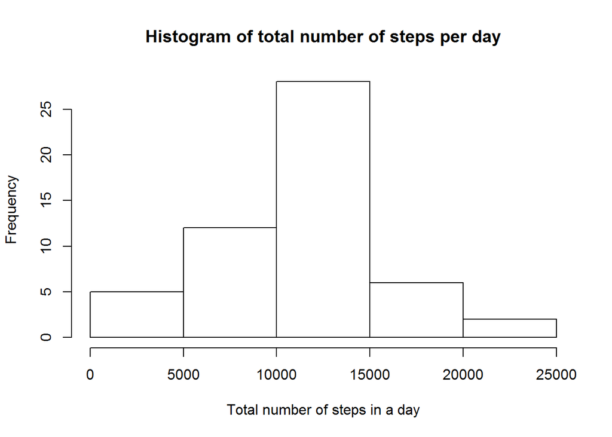

```r
hist(temp3$steps,main="Histogram of total number of steps per day",
    xlab="Total number of steps in a day")
```

## 3. Calculate and report the mean and median of the total number of steps taken per day

```r
summary(temp3)
```

```
##      date               steps
##  Length:61          Min.   :   41
##  Class :character   1st Qu.: 8841
##  Mode  :character   Median :10765
##                     Mean   :10766
##                     3rd Qu.:13294
##                     Max.   :21194
##                     NA's   :8
```

# What is the average daily activity pattern?

## 1. Make a time series plot (i.e. type = “l”) of the 5-minute interval (x-axis) and the average number of steps taken, averaged across all days (y-axis)

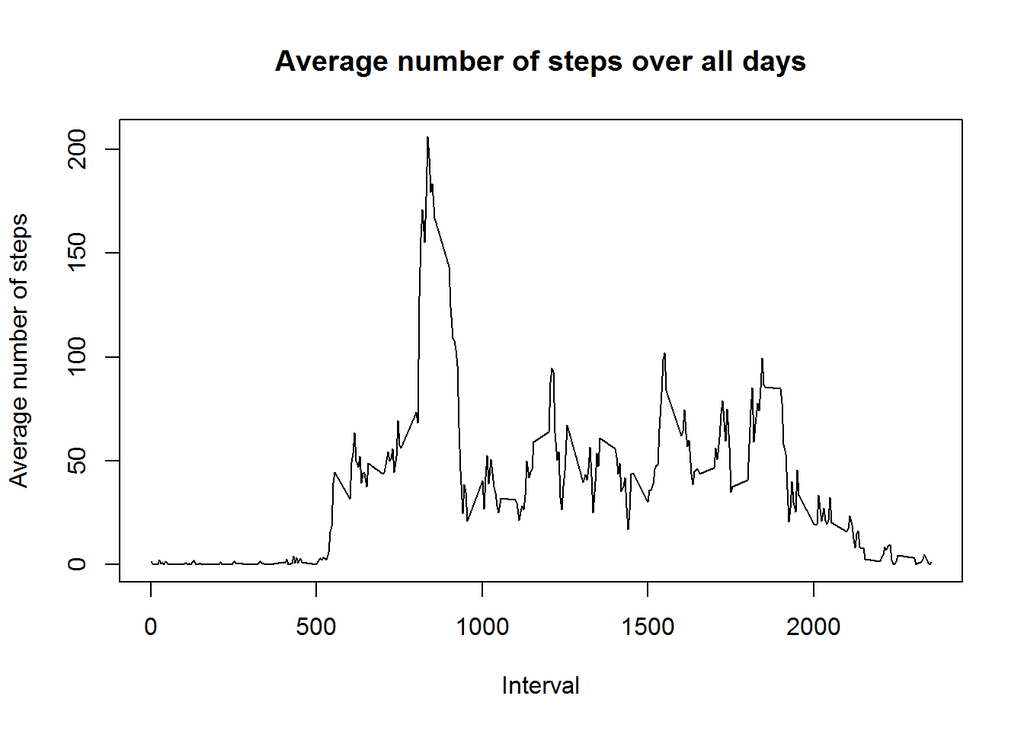

```r
# Data preparation for plot
mean_steps_interval <- temp2[,  lapply(.SD, mean, na.rm =T), .SDcols = 1, by = interval]
# create a time series plot
plot(mean_steps_interval$interval, mean_steps_interval$steps, type='l',
      main="Average number of steps over all days", xlab="Interval",
      ylab="Average number of steps")
```

```r
temp2[, .(Median_Total_Number= lapply(.SD, median)), .SDcols = 1, by = date]
```

```
##           date Median_Total_Number
##  1: 2012-10-01                  NA
##  2: 2012-10-02                   0
##  3: 2012-10-03                   0
##  4: 2012-10-04                   0
##  5: 2012-10-05                   0
##  6: 2012-10-06                   0
##  7: 2012-10-07                   0
##  8: 2012-10-08                  NA
##  9: 2012-10-09                   0
## 10: 2012-10-10                   0
## 11: 2012-10-11                   0
## 12: 2012-10-12                   0
## 13: 2012-10-13                   0
## 14: 2012-10-14                   0
```

[output cut: 48 more lines]

## 2. Which 5-minute interval, on average across all the days in the dataset, contains the maximum number of steps?

```r
max_row <- which.max(mean_steps_interval$steps)
mean_steps_interval[max_row]
```

```
##    interval    steps
## 1:      835 206.1698
```

# Imputing missing values

## 1. Calculate and report the total number of missing values in the dataset (i.e. the total number of rows with NAs)

```r
table(is.na(temp2))
```

```
##
## FALSE  TRUE
## 50400  2304
```

## 2. Devise a strategy for filling in all of the missing values in the dataset.

```r
imputed_temp <- copy(temp2)
for (i in 1:nrow(imputed_temp)) {
if (is.na(imputed_temp$steps[i])) {
interval_value <- imputed_temp$interval[i]
steps_value <- mean_steps_interval[mean_steps_interval$interval == interval_value, ]
imputed_temp$steps[i] <- steps_value$steps
}
}
```

## 3. Create a new dataset that is equal to the original dataset but with the missing data filled in.

```r
imputed_mean_steps_date <- imputed_temp[,  lapply(.SD, sum, na.rm =T), .SDcols = 1, by = date]
```

## 4. Make a histogram of the total number of steps taken each day and Calculate and report the mean and median total number of steps taken per day. Do these values differ from the estimates from the first part of the assignment? What is the impact of imputing missing data on the estimates of the total daily number of steps?

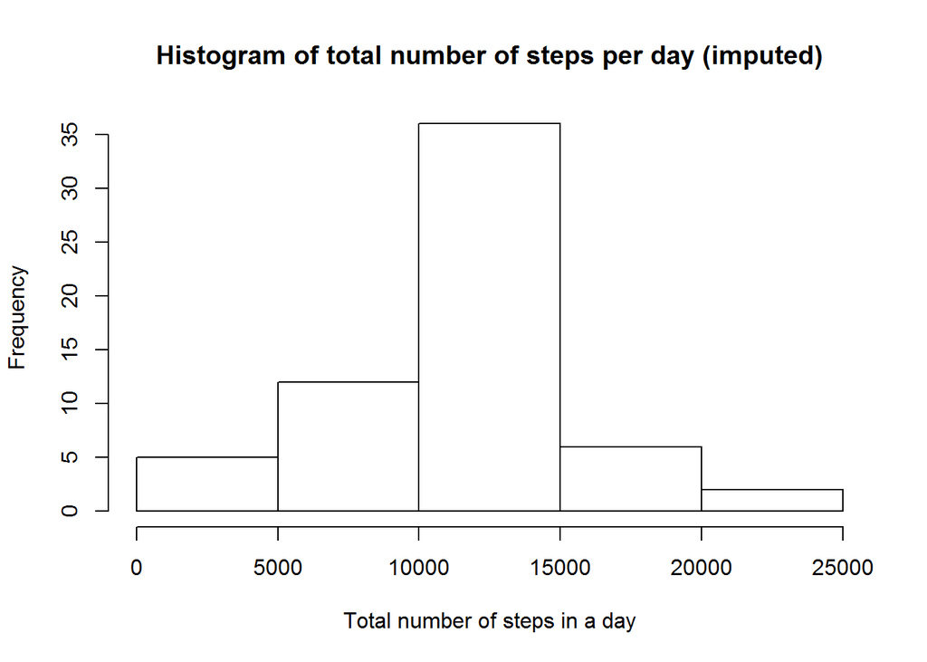

```r
hist(imputed_mean_steps_date$steps, main="Histogram of total number of steps per day (imputed)",xlab="Total number of steps in a day")
```

```r
# get mean of imputed data
mean(imputed_mean_steps_date$steps)
```

```
## [1] 10766.19
```

```r
# get median of imputed date
median(imputed_mean_steps_date$steps)
```

```
## [1] 10766.19
```

```r
# get mean of imputed data with NAs
mean(temp3$steps, na.rm = T)
```

```
## [1] 10766.19
```

```r
# get median of imputed data with NAs
median(temp3$steps, na.rm = T)
```

```
## [1] 10765
```

```r
# create a and assin the days
imputed_mean_steps_date$days <- weekdays(as.Date(imputed_mean_steps_date$date))
imputed_temp$days <- weekdays(as.Date(imputed_temp$date))
```

```r
# create the two files of the weekdays and weekend
 Weekend <- imputed_mean_steps_date[days %in% c("Saturday", "Sunday")]
 Weekday <- imputed_mean_steps_date[!days %in% c("Saturday", "Sunday")]
```

```r
temp4<-  aggregate(steps ~ interval + days, imputed_temp, mean)
setDT(temp4)
Weekdays<- temp4[!days %in% c("Saturday", "Sunday")]
Weekends<- temp4[days %in% c("Saturday", "Sunday")]
```

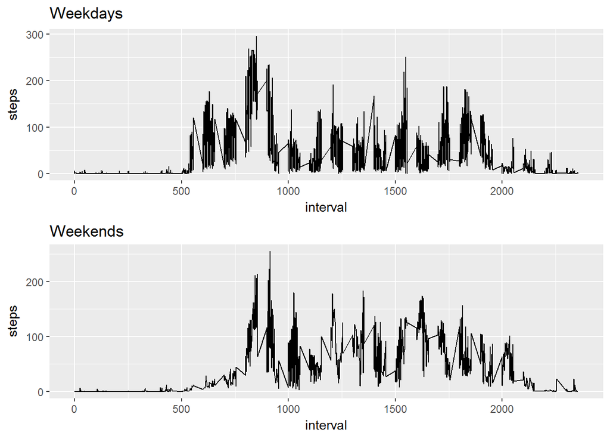

```r
p1 <-ggplot(Weekdays, aes( interval, steps))+ geom_line()+ ggtitle("Weekdays")
p2 <-ggplot(Weekends, aes( interval, steps))+ geom_line()+ ggtitle("Weekends")
grid.arrange(p1, p2)
```